# A Replication of Karlan and List (2007)

Author

Sangho Lee

Published

April 12, 2024

## Introduction

Dean Karlan at Yale and John List at the University of Chicago conducted a field experiment to test the effectiveness of different fundraising letters. They sent out 50,000 fundraising letters to potential donors, randomly assigning each letter to one of three treatments: a standard letter, a matching grant letter, or a challenge grant letter. They published the results of this experiment in the *American Economic Review* in 2007. The article and supporting data are available from the [AEA website](https://www.aeaweb.org/articles?id=10.1257/aer.97.5.1774) and from Innovations for Poverty Action as part of [Harvard’s Dataverse](https://dataverse.harvard.edu/dataset.xhtml?persistentId=doi:10.7910/DVN/27853&version=4.2).

This project seeks to replicate their results.

## Data

### Description

#### I will now load the data and preview the first few rows. Since the data is in .dta format, I’m going to use the haven package to import it into this environment. Then, I will display the top 10 rows as a sample.

```r
library(haven)
library(tidyverse)
library(magrittr)
library(scales)
```

```r
data <- haven::read_dta("karlan_list_2007.dta")

# Create a table
data %>%
  head(10) %>%
  knitr::kable()
```

| treatment | control | ratio | ratio2 | ratio3 | size | size25 | size50 | size100 | sizeno | ask | askd1 | askd2 | askd3 | ask1 | ask2 | ask3 | amount | gave | amountchange | hpa | ltmedmra | freq | years | year5 | mrm2 | dormant | female | couple | state50one | … |
| --- | --- | --- | --- | --- | --- | --- | --- | --- | --- | --- | --- | --- | --- | --- | --- | --- | --- | --- | --- | --- | --- | --- | --- | --- | --- | --- | --- | --- | --- | --- |
| 0 | 1 | 0 | 0 | 0 | 0 | 0 | 0 | 0 | 0 | 0 | 0 | 0 | 0 | 55 | 70 | 85 | 0 | 0 | -45 | 45 | 0 | 2 | 4 | 0 | 31 | 1 | 0 | 0 | 0 | … |
| 0 | 1 | 0 | 0 | 0 | 0 | 0 | 0 | 0 | 0 | 0 | 0 | 0 | 0 | 25 | 35 | 50 | 0 | 0 | -25 | 25 | 1 | 2 | 3 | 0 | 5 | 0 | 0 | 0 | 0 | … |
| 1 | 0 | 1 | 0 | 0 | 3 | 0 | 0 | 1 | 0 | 1 | 1 | 0 | 0 | 55 | 70 | 85 | 0 | 0 | -50 | 50 | 0 | 3 | 2 | 0 | 6 | 0 | 0 | 0 | 0 | … |
| 1 | 0 | 1 | 0 | 0 | 4 | 0 | 0 | 0 | 1 | 1 | 1 | 0 | 0 | 55 | 70 | 85 | 0 | 0 | -25 | 50 | 1 | 15 | 8 | 1 | 1 | 0 | 0 | 0 | 0 | … |
| 1 | 0 | 1 | 0 | 0 | 2 | 0 | 1 | 0 | 0 | 1 | 1 | 0 | 0 | 35 | 45 | 55 | 0 | 0 | -15 | 25 | 1 | 42 | 95 | 1 | 24 | 1 | 1 | 0 | 0 | … |
| 0 | 1 | 0 | 0 | 0 | 0 | 0 | 0 | 0 | 0 | 0 | 0 | 0 | 0 | 95 | 120 | 145 | 0 | 0 | -45 | 90 | 0 | 20 | 10 | 1 | 3 | 0 | 0 | 0 | 0 | … |
| 1 | 0 | 1 | 0 | 0 | 1 | 1 | 0 | 0 | 0 | 3 | 0 | 0 | 1 | 125 | 160 | 190 | 0 | 0 | -50 | 100 | 0 | 12 | 8 | 1 | 4 | 0 | 1 | 0 | 0 | … |
| 1 | 0 | 2 | 1 | 0 | 3 | 0 | 0 | 1 | 0 | 3 | 0 | 0 | 1 | 75 | 95 | 120 | 0 | 0 | -65 | 65 | 0 | 13 | 16 | 1 | 4 | 0 | 0 | 0 | 0 | … |
| 1 | 0 | 2 | 1 | 0 | 4 | 0 | 0 | 0 | 1 | 2 | 0 | 1 | 0 | 250 | 315 | 375 | 0 | 0 | -100 | 200 | 0 | 28 | 19 | 1 | 6 | 0 | 0 | 0 | 0 | … |
| 1 | 0 | 1 | 0 | 0 | 1 | 1 | 0 | 0 | 0 | 2 | 0 | 1 | 0 | 150 | 190 | 225 | 0 | 0 | -125 | 125 | 0 | 4 | 7 | 1 | 35 | 1 | 0 | 0 | 0 | … |

#### I am also going to load the Python packages that I will need to complete the work in this environment.

```python
import pandas as pd
import numpy as np
import pyrsm as rsm
import matplotlib.pyplot as plt
import statsmodels.api as sm
```

**Variable Definitions**

| Variable | Description |
| --- | --- |
| `treatment` | Treatment |
| `control` | Control |
| `ratio` | Match ratio |
| `ratio2` | 2:1 match ratio |
| `ratio3` | 3:1 match ratio |
| `size` | Match threshold |
| `size25` | $25,000 match threshold |
| `size50` | $50,000 match threshold |
| `size100` | $100,000 match threshold |
| `sizeno` | Unstated match threshold |
| `ask` | Suggested donation amount |
| `askd1` | Suggested donation was highest previous contribution |
| `askd2` | Suggested donation was 1.25 x highest previous contribution |
| `askd3` | Suggested donation was 1.50 x highest previous contribution |
| `ask1` | Highest previous contribution (for suggestion) |
| `ask2` | 1.25 x highest previous contribution (for suggestion) |
| `ask3` | 1.50 x highest previous contribution (for suggestion) |
| `amount` | Dollars given |
| `gave` | Gave anything |
| `amountchange` | Change in amount given |
| `hpa` | Highest previous contribution |
| `ltmedmra` | Small prior donor: last gift was less than median $35 |
| `freq` | Number of prior donations |
| `years` | Number of years since initial donation |
| `year5` | At least 5 years since initial donation |
| `mrm2` | Number of months since last donation |
| `dormant` | Already donated in 2005 |
| `female` | Female |
| `couple` | Couple |
| `state50one` | State tag: 1 for one observation of each of 50 states; 0 otherwise |
| `nonlit` | Nonlitigation |
| `cases` | Court cases from state in 2004-5 in which organization was involved |
| `statecnt` | Percent of sample from state |
| `stateresponse` | Proportion of sample from the state who gave |
| `stateresponset` | Proportion of treated sample from the state who gave |
| `stateresponsec` | Proportion of control sample from the state who gave |
| `stateresponsetminc` | stateresponset - stateresponsec |
| `perbush` | State vote share for Bush |
| `close25` | State vote share for Bush between 47.5% and 52.5% |
| `red0` | Red state |
| `blue0` | Blue state |
| `redcty` | Red county |
| `bluecty` | Blue county |
| `pwhite` | Proportion white within zip code |
| `pblack` | Proportion black within zip code |
| `page18_39` | Proportion age 18-39 within zip code |
| `ave_hh_sz` | Average household size within zip code |
| `median_hhincome` | Median household income within zip code |
| `powner` | Proportion house owner within zip code |
| `psch_atlstba` | Proportion who finished college within zip code |
| `pop_propurban` | Proportion of population urban within zip code |

### Balance Test

As an ad hoc test of the randomization mechanism, I provide a series of tests that compare aspects of the treatment and control groups to assess whether they are statistically significantly different from one another.

#### I’m going to conduct t-tests and linear regressions on several variables, such as months since last donation, to determine if there are statistically significant differences between the treatment and control groups at the 95% confidence level. For the t-tests, I will use the t.test function in R to analyze the data. For the linear regressions, I will utilize the pyrsm package in Python to examine the impact of the treatment by regressing variables like months since last donation against the treatment group and observing the coefficient of the treatment variable. This approach will allow me to confirm that both methods yield consistent results.

1. mrm2 variable

```r
t.test(mrm2 ~ treatment, data = data, conf.level = 0.95)
```

```
    Welch Two Sample t-test

data:  mrm2 by treatment
t = -0.11953, df = 33394, p-value = 0.9049
alternative hypothesis: true difference in means between group 0 and group 1 is not equal to 0
95 percent confidence interval:
 -0.2381015  0.2107298
sample estimates:
mean in group 0 mean in group 1
       12.99814        13.01183
```

```python
lm = rsm.model.regress(
  data = data,
  rvar = "mrm2",
  evar = "treatment"
)

lm.summary()
```

```
Linear regression (OLS)
Data                 : Not provided
Response variable    : mrm2
Explanatory variables: treatment
Null hyp.: the effect of x on mrm2 is zero
Alt. hyp.: the effect of x on mrm2 is not zero

           coefficient  std.error  t.value p.value
Intercept        13.00      0.094  138.979  < .001  ***
treatment         0.01      0.115    0.119   0.905

Signif. codes:  0 '***' 0.001 '**' 0.01 '*' 0.05 '.' 0.1 ' ' 1

R-squared: 0.0, Adjusted R-squared: -0.0
F-statistic: 0.014 df(1, 50080), p.value 0.905
Nr obs: 50,082
```

- P-value: Both methods yield a p-value of approximately 0.905
- Interpretation: There are no significant differences between the treatment and control groups for “mrm2” (months since last donation). This suggests effective randomization, indicating that any observed treatment effects are likely due to the treatment itself rather than pre-existing group differences.
2. pwhite variable

```r
t.test(pwhite ~ treatment, data = data, conf.level = 0.95)
```

```
    Welch Two Sample t-test

data:  pwhite by treatment
t = 0.55912, df = 31876, p-value = 0.5761
alternative hypothesis: true difference in means between group 0 and group 1 is not equal to 0
95 percent confidence interval:
 -0.002287046  0.004112602
sample estimates:
mean in group 0 mean in group 1
      0.8202078       0.8192950
```

```python
lm = rsm.model.regress(
  data = data,
  rvar = "pwhite",
  evar = "treatment"
)

lm.summary()
```

```
Linear regression (OLS)
Data                 : Not provided
Response variable    : pwhite
Explanatory variables: treatment
Null hyp.: the effect of x on pwhite is zero
Alt. hyp.: the effect of x on pwhite is not zero

           coefficient  std.error  t.value p.value
Intercept         0.82      0.001  616.281  < .001  ***
treatment        -0.00      0.002   -0.560   0.575

Signif. codes:  0 '***' 0.001 '**' 0.01 '*' 0.05 '.' 0.1 ' ' 1

R-squared: 0.0, Adjusted R-squared: -0.0
F-statistic: 0.314 df(1, 48215), p.value 0.575
Nr obs: 48,217
```

- P-value: Both the t-test and linear regression show a p-value around 0.575.
- Interpretation: There is no significant difference in the proportion of white individuals between the treatment and control groups, indicating that the randomization was successful in creating comparable groups regarding racial composition.
3. female variable

```r
t.test(female ~ treatment, data = data, conf.level = 0.95)
```

```
    Welch Two Sample t-test

data:  female by treatment
t = 1.7535, df = 32451, p-value = 0.07952
alternative hypothesis: true difference in means between group 0 and group 1 is not equal to 0
95 percent confidence interval:
 -0.0008888548  0.0159826921
sample estimates:
mean in group 0 mean in group 1
      0.2826978       0.2751509
```

```python
lm = rsm.model.regress(
  data = data,
  rvar = "female",
  evar = "treatment"
)

lm.summary()
```

```
Linear regression (OLS)
Data                 : Not provided
Response variable    : female
Explanatory variables: treatment
Null hyp.: the effect of x on female is zero
Alt. hyp.: the effect of x on female is not zero

           coefficient  std.error  t.value p.value
Intercept         0.28      0.004   80.688  < .001  ***
treatment        -0.01      0.004   -1.758   0.079    .

Signif. codes:  0 '***' 0.001 '**' 0.01 '*' 0.05 '.' 0.1 ' ' 1

R-squared: 0.0, Adjusted R-squared: 0.0
F-statistic: 3.092 df(1, 48970), p.value 0.079
Nr obs: 48,972
```

- P-value: The t-test has a p-value of 0.07952 and the linear regression also shows a p-value of 0.079.
- Interpretation: The results suggest a marginal difference in the proportion of females between the treatment and control groups that approaches but does not reach conventional levels of statistical significance (p < 0.05).

##### Understanding the T-value and P-value

- T-value (1.7535): The t-value measures the ratio of the difference between the group means to the standard error of the difference. A t-value of 1.7535 indicates that the difference between the group means (for the proportion of females in treatment versus control) is 1.7535 times the standard error away from zero. The sign (+) of the t-value suggests that the mean proportion of females in the treatment group is slightly lower than in the control group, given the negative coefficient in the regression output.
- P-value (0.07952): The p-value tells us the probability of observing a t-value as extreme as 1.7535 (or more) if the null hypothesis were true which was there is no difference in the proportion of females between groups.

## Experimental Results

### Charitable Contribution Made

First, I analyze whether matched donations lead to an increased response rate of making a donation.

#### I’m going to create a bar plot that visualizes the proportion of people who donated, with two separate bars representing the treatment and control groups. This will allow for a clear comparison of the donation rates between the two groups

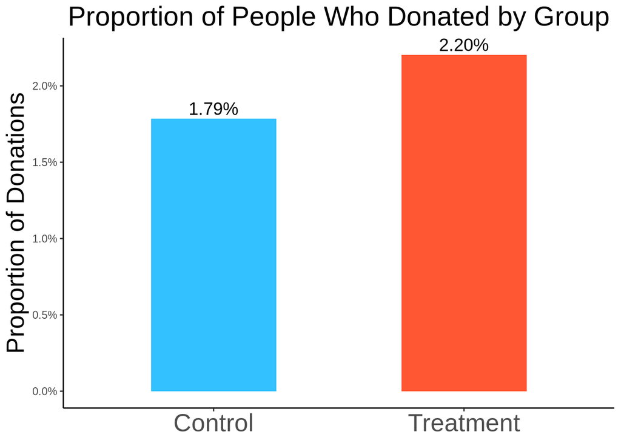

```r
# Calculate the proportion of donations in the treatment and control groups using dplyr
plot_data <- data %>%
  group_by(treatment) %>%
  summarise(Proportion_Donated = mean(gave == 1, na.rm = TRUE)) %>%
  mutate(Group = ifelse(treatment == 1, "Treatment", "Control")) %>%
  select(Group, Proportion_Donated)

# Generate the bar plot using ggplot2
ggplot(plot_data, aes(x = Group, y = Proportion_Donated, fill = Group)) +
  geom_bar(stat = "identity", position = "dodge", width = 0.5) +
  geom_text(aes(label=scales::percent(Proportion_Donated)), vjust=-0.3, size=5) +
  scale_y_continuous(labels = scales::percent_format()) +
  labs(y = "Proportion of Donations", title = "Proportion of People Who Donated by Group") +
  theme_classic() +
  theme(
    plot.title = element_text(hjust = 0.5, size = 22),
    axis.title.y = element_text(size = 20),
    axis.text.x = element_text(size = 20),
    axis.title.x = element_blank(),
    legend.position = "none"
  ) +
  scale_fill_manual(values = c("Treatment" = "#FF5733", "Control" = "#33C1FF"))
```

#### I’m going to perform a t-test to compare the treatment and control groups based on whether a charitable donation was made. Additionally, I will conduct a linear regression to analyze the same data. After obtaining the statistical outcomes, I will interpret these results in the context of the experiment. Specifically, if the results show a statistically significant difference, I’ll discuss what these findings suggest about human behavior towards charitable giving, focusing more on qualitative insights rather than numerical data.

```r
t.test(gave ~ treatment, data = data, var.equal = FALSE)
```

```
    Welch Two Sample t-test

data:  gave by treatment
t = -3.2095, df = 36577, p-value = 0.001331
alternative hypothesis: true difference in means between group 0 and group 1 is not equal to 0
95 percent confidence interval:
 -0.006733310 -0.001627399
sample estimates:
mean in group 0 mean in group 1
     0.01785821      0.02203857
```

```python
lm = rsm.model.regress(
  data = data,
  rvar = "gave",
  evar = "treatment"
)

lm.summary()
```

```
Linear regression (OLS)
Data                 : Not provided
Response variable    : gave
Explanatory variables: treatment
Null hyp.: the effect of x on gave is zero
Alt. hyp.: the effect of x on gave is not zero

           coefficient  std.error  t.value p.value
Intercept         0.02      0.001   16.225  < .001  ***
treatment         0.00      0.001    3.101   0.002   **

Signif. codes:  0 '***' 0.001 '**' 0.01 '*' 0.05 '.' 0.1 ' ' 1

R-squared: 0.0, Adjusted R-squared: 0.0
F-statistic: 9.618 df(1, 50081), p.value 0.002
Nr obs: 50,083
```

#### The t-test and linear regression both show that the treatment group had a slightly higher donation rate (2.2%) compared to the control group (1.8%). This statistically significant difference (p-value = 0.0013 for the t-test) suggests that even a modest intervention can effectively increase the likelihood of donating. This demonstrates how small nudges, such as targeted reminders, can influence human behavior and enhance donation rates, which is crucial for organizations aiming to improve their fundraising outcomes.

#### I’m going to conduct a probit regression where the outcome variable is whether a charitable donation was made, and the explanatory variable is whether individuals were assigned to the treatment or control group.

```python
# Create the dependent and independent variables
X = data[['treatment']]  # independent variable
X = sm.add_constant(X)  # adding a constant
y = data['gave']  # dependent variable

# Fit a probit model
probit_model = sm.Probit(y, X).fit()
```

```
Optimization terminated successfully.
         Current function value: 0.100443
         Iterations 7
```

```python
# Print the summary of the model
print(probit_model.summary())
```

```
                          Probit Regression Results
==============================================================================
Dep. Variable:                   gave   No. Observations:                50083
Model:                         Probit   Df Residuals:                    50081
Method:                           MLE   Df Model:                            1
Date:                Fri, 12 Apr 2024   Pseudo R-squ.:               0.0009783
Time:                        10:44:46   Log-Likelihood:                -5030.5
converged:                       True   LL-Null:                       -5035.4
Covariance Type:            nonrobust   LLR p-value:                  0.001696
==============================================================================
                 coef    std err          z      P>|z|      [0.025      0.975]
------------------------------------------------------------------------------
const         -2.1001      0.023    -90.073      0.000      -2.146      -2.054
treatment      0.0868      0.028      3.113      0.002       0.032       0.141
==============================================================================
```

- Probit Regression Explained: Probit regression is a type of regression used in statistics to analyze binary (two outcome) variables. In this context, it models the probability that someone made a charitable donation based on whether they were in the treatment group or not.

Key Elements of the Output:

- Dependent Variable (gave): This is what we’re trying to predict: whether or not someone gave a donation (1 if yes, 0 if no).
- Number of Observations (50,083): This is the total number of data points used in the model.
- Model (Probit): The type of model used, which in this case uses a Probit link function. This function maps any input from minus infinity to infinity to a 0 to 1 range, fitting the binary nature of the dependent variable.
- MLE (Maximum Likelihood Estimation): This is the method used to fit the model, optimizing to find the parameter values that maximize the likelihood of the data given the model.
- Coefficients:
1. const (-2.1001): This is the intercept, or baseline log odds of donating when all predictors are 0 (i.e., not in the treatment group). A negative value indicates a low baseline probability of donation.
2. treatment (0.0868): This coefficient shows the effect of being in the treatment group. It suggests that being in the treatment group increases the likelihood of donating compared to the control group.
- Standard Error (std err): These values (0.023 for const and 0.028 for treatment) measure the average distance that the estimated values (coefficients) fall from the actual value. Smaller standard errors suggest more precise estimates.
- Z-value: This is the test statistic used to determine whether to reject the null hypothesis (that the coefficient is zero, implying no effect). For the treatment, a z-value of 3.113 indicates a statistically significant effect.
- P-value: For treatment (0.002), this value is very small, indicating strong evidence against the null hypothesis. It suggests that the treatment effect is statistically significant and not due to random chance.
- Confidence Interval: For treatment ([0.032, 0.141]), this range gives us a 95% confidence level that the true coefficient falls within this interval. It confirms that the effect is positive and fairly precise.

## Simulation Experiment

Suppose the true distribution of respondents who do not get a charitable donation match is Bernoulli with probability p=0.018 that a donation is made.

Further suppose that the true distribution of respondents who do get a charitable donation match of any size is Bernoulli with probability p=0.022 that a donation is made.